# Exercise 1

```python
import numpy as np
import pandas as pd
import matplotlib.pyplot as plt
```

## PART A - NumPy

- **(10 points)** Create a random dataset with 1000 rows and 6 columns by generating the columns one at a time and then concatenating them to create the dataset.

```python
np.random.RandomState(42)

dataset = np.random.randn(1000, 1)

for col in range(5):
    dataset = np.concatenate([dataset, np.random.randint(-10, 10, size=(1000, 1))], axis=1)

print(dataset.shape)
print(dataset)
```

```
(1000, 6)
[[  1.48971428   7.          -6.           4.          -9.
    6.        ]
 [  1.03360791   2.          -5.          -1.          -7.
    0.        ]
 [ -0.73108714  -6.           2.          -8.          -5.
    0.        ]
 ...
 [  0.56599351   4.           5.          -6.          -4.
   -3.        ]
 [  1.41914333  -9.           3.          -6.          -2.
    6.        ]
 [  0.18750306  -4.           7.         -10.          -5.
  -10.        ]]
```

- **(8 points)** Shuffle the dataset.

```python
np.random.shuffle(dataset)

print(dataset.shape)
print(dataset)
```

```
(1000, 6)
[[ -0.35735585   4.          -9.          -6.           9.
    8.        ]
 [  0.80748558  -2.          -6.          -5.          -7.
    5.        ]
 [ -0.7155856    7.           6.           5.          -1.
   -5.        ]
 ...
 [  0.40419939  -9.          -1.          -8.         -10.
   -2.        ]
 [  0.10042853  -2.           9.          -5.           9.
  -10.        ]
 [  0.40143978   7.           7.          -2.          -1.
   -2.        ]]
```

- **(10 points)** Split it using a 60/25/15 split into three sets: training, validation and test.

```python
#training, validation, test size percentages
training, validation, test = 0.6, 0.25, 0.15

#get the 2 split indexes (split at 60% and 85%)
split_ndx1, split_ndx2 = int(training * len(dataset)), int((training + validation) * len(dataset))

training_set, validation_set, test_set = dataset[0:split_ndx1,:], dataset[split_ndx1:split_ndx2,:], dataset[split_ndx2:,:]
print(f'''
Training Set shape: {training_set.shape}
Validation Set shape: {validation_set.shape}
Test Set shape: {test_set.shape}
''')
```

```
Training Set shape: (600, 6)
Validation Set shape: (250, 6)
Test Set shape: (150, 6)
```

- **(7 points)** Standardize every column in the training set by subtracting every column by its mean and dividing the result by its standard deviation.

```python
means = []
stds = []

for col in range(training_set.shape[1]):
    col_mean = training_set[:,col].mean()
    col_std = training_set[:,col].std()

    means.append(col_mean)
    stds.append(col_std)

    training_set[:,col] -= col_mean
    training_set[:,col] /= col_std

print(training_set.shape)
print(training_set)
```

```
(600, 6)
[[-0.33968552  0.70162595 -1.45601419 -0.95886812  1.63216478  1.44103996]
 [ 0.82426784 -0.3238931  -0.94562947 -0.78367906 -1.13275174  0.92841705]
 [-0.69764215  1.21438547  1.09590942  0.96821154 -0.09590804 -0.78032598]
 ...
 [-0.08176498  1.38530531 -0.43524475 -0.25811188 -1.30555902  1.27016565]
 [-0.11442103 -0.66573278 -1.62614243 -0.43330094  1.28655022  0.24491983]
 [ 1.91228521 -0.15297326  1.60629414 -1.13405718 -1.13275174  0.75754274]]
```

- **(5 points)** Do the same with validation and test sets but using the mean and standard deviation from the training set.

```python
for col in range(training_set.shape[1]):
    #validation
    validation_set[:,col] -= means[col]
    validation_set[:,col] /= stds[col]

    #test set
    test_set[:,col] -= means[col]
    test_set[:,col] /= stds[col]

print(validation_set.shape)
print(test_set.shape)
```

```
(250, 6)
(150, 6)
```

## PART B - Pandas

- **(6 points)** Take the 1000-row dataset you created in the Numpy part and create a DataFrame with it. Give the columns the names `a` to `f`.

```python
df = pd.DataFrame(dataset, columns=['a', 'b', 'c', 'd', 'e', 'f'])
df.head()
```

|  | a | b | c | d | e | f |
| --- | --- | --- | --- | --- | --- | --- |
| 0 | -0.339686 | 0.701626 | -1.456014 | -0.958868 | 1.632165 | 1.441040 |
| 1 | 0.824268 | -0.323893 | -0.945629 | -0.783679 | -1.132752 | 0.928417 |
| 2 | -0.697642 | 1.214385 | 1.095909 | 0.968212 | -0.095908 | -0.780326 |
| 3 | -0.953325 | 0.188866 | 0.925781 | -1.484435 | -0.614330 | 1.270166 |
| 4 | 1.277376 | -1.007572 | -1.115758 | 1.143401 | 0.076899 | 0.244920 |

- **(6 points)** Shuffle the DataFrame.

```python
df = df.sample(len(df))
df
```

|  | a | b | c | d | e | f |
| --- | --- | --- | --- | --- | --- | --- |
| 315 | 0.216128 | -0.836653 | -0.435245 | 0.267455 | -1.132752 | 1.099291 |
| 464 | -0.106903 | 1.043466 | 1.266038 | -1.309246 | -0.268715 | -1.634698 |
| 898 | -0.146065 | 0.017947 | -1.456014 | 1.318590 | 0.249707 | 0.415794 |
| 456 | 1.362824 | 0.017947 | 1.606294 | -0.082923 | 0.768128 | 1.611914 |
| 180 | -0.078168 | 0.701626 | 0.585525 | 0.793022 | -1.132752 | -0.780326 |
| ... | ... | ... | ... | ... | ... | ... |
| 950 | -0.612637 | -0.665733 | 1.095909 | 1.318590 | -0.095908 | 0.928417 |
| 460 | 1.233206 | -0.323893 | -0.435245 | -1.309246 | -1.132752 | 0.757543 |
| 416 | -1.492252 | -1.691252 | 0.925781 | 0.092266 | -0.614330 | -0.780326 |
| 770 | 0.310259 | -1.349412 | 0.925781 | 1.668968 | -0.959944 | -0.438577 |
| 648 | -0.965559 | 0.188866 | 0.755653 | 0.793022 | 1.632165 | -1.634698 |

1000 rows × 6 columns

- **(8 points)** Break it using a 60/25/15 split into three dataframes: training, validation, and test.

```python
print(training, validation, test)
print(split_ndx1, split_ndx2)
```

```
0.6 0.25 0.15
600 850
```

```python
df_train = df.iloc[:split_ndx1,:]
df_validation = df.iloc[split_ndx1:split_ndx2,:]
df_test = df.iloc[split_ndx2:,:]

print(df_train.shape, df_validation.shape, df_test.shape)
```

```
(600, 6) (250, 6) (150, 6)
```

- **(6 points)** Standardize every column in the training dataframe by subtracting every column by its mean and dividing the result by its standard deviation. Do the same with validation and test dataframes but using the mean and standard deviation from the training dataframe.

```python
#training
df_train = df_train - df_train.mean()
df_train = df_train / df_train.std()
print(df_train)
```

```
            a         b         c         d         e         f
315  0.188940 -0.849240 -0.415387  0.241070 -1.146676  1.097038
464 -0.148357  1.069618  1.294024 -1.304985 -0.294340 -1.607524
898 -0.189248  0.022968 -1.441033  1.271774  0.217062  0.420897
456  1.386273  0.022968  1.635906 -0.102498  0.728463  1.604143
180 -0.118353  0.720735  0.610260  0.756422 -1.146676 -0.762348
..        ...       ...       ...       ...       ...       ...
258  0.192987 -0.674798  1.123083  1.099990  1.410332  1.435108
849 -0.387864  0.197410  0.610260  0.412854  1.580800  1.097038
345 -1.470282  1.069618 -0.244446  1.099990 -0.123873 -0.255243
2   -0.765184  1.244060  1.123083  0.928206 -0.123873 -0.762348
311  1.191622  1.069618 -0.757269 -1.648553 -1.487611  0.420897

[600 rows x 6 columns]
```

```python
#validation and test
df_validation -= df_train.mean()
df_validation /= df_train.std()
print(df_validation)

df_test -= df_train.mean()
df_test /= df_train.std()
print(df_test)
```

```
            a         b         c         d         e         f
713  0.636865 -1.520332 -0.775501 -0.433301  0.768128 -0.267703
502  0.769824  1.556225  1.436166  0.793022  1.459358  1.611914
494  0.419589 -0.836653  0.415396 -0.608490  0.422514 -1.122075
688 -2.256372  1.385305  0.245268 -1.309246  0.249707  0.757543
742 -0.746229  0.359786  1.095909  1.143401  0.595321  0.757543
..        ...       ...       ...       ...       ...       ...
272 -1.433069  1.556225 -0.605373  0.267455  1.113743  1.099291
990  0.656499  1.043466 -0.945629 -1.659624  0.249707  1.099291
602  0.227574 -0.494813  1.606294  1.318590  0.249707 -0.609452
283 -0.239749 -0.152973 -0.775501  0.092266 -1.651174  0.757543
71  -1.407946 -1.349412  0.075140 -1.309246 -1.651174 -1.634698

[250 rows x 6 columns]
            a         b         c         d         e         f
191 -0.269842  1.214385 -0.945629 -0.783679 -0.441523  1.270166
193 -0.071604  0.359786 -0.094988 -0.608490 -1.132752 -1.292949
816 -1.479733 -1.691252 -0.775501  1.493779  1.459358 -0.951200
933  1.005721 -0.494813 -0.945629  0.968212 -1.305559  0.586668
185  1.363297  0.701626 -1.115758 -1.659624 -0.959944  1.611914
..        ...       ...       ...       ...       ...       ...
950 -0.612637 -0.665733  1.095909  1.318590 -0.095908  0.928417
460  1.233206 -0.323893 -0.435245 -1.309246 -1.132752  0.757543
416 -1.492252 -1.691252  0.925781  0.092266 -0.614330 -0.780326
770  0.310259 -1.349412  0.925781  1.668968 -0.959944 -0.438577
648 -0.965559  0.188866  0.755653  0.793022  1.632165 -1.634698

[150 rows x 6 columns]
```

- **(4 points)** Save all three dataframes into their own `.csv` files.

```python
df_train.to_csv('training.csv')
df_validation.to_csv('validation.csv')
df_test.to_csv('test.csv')
```

## PART C - Matplotlib

- **(27 points)** Plot the following functions using $2\ by\ 3$ subplots. Each plot must have its own title, and its own x and y labels. Make also sure that each plot enough of the function to show its behavior.
  - $f(x) = 3 x^2 + 10$
  - $f(x) = \frac{1}{1 + e^{-x}}$
  - $f(z) = max(\alpha z, z)$ where $\alpha = 0.01$ where $max(...)$ returns the maximum of its arguments.
  - $f(x) = sin(x^2)$
  - $f(x) = cos(x) + ln(x)$
  - $f(x) = tanh(x)$

```python
[3*x**2+10 for x in range(-5, 5)]
```

```
[85, 58, 37, 22, 13, 10, 13, 22, 37, 58]
```

```python
def func1(x_vals):
    return [(3*x**2 + 10) for x in x_vals]

def func2(x_vals):
    return [(1 / (1 + np.exp(-x))) for x in x_vals]

def func3(x_vals):
    return [max(0.01*x, x) for x in x_vals]

def func4(x_vals):
    return [np.sin(x**2) for x in x_vals]

def func5(x_vals):
    return [np.cos(x) + np.log(x) for x in x_vals]

def func6(x_vals):
    return [np.tanh(x) for x in x_vals]
```

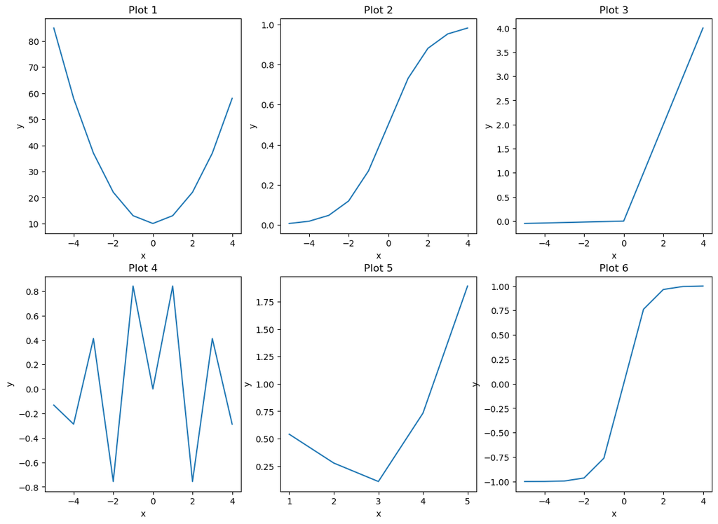

```python
fig, subfigs = plt.subplots(2,3, figsize=(14,10))

x = range(-5, 5)

subfigs[0][0].plot(x, func1(x))
subfigs[0][0].set_title('Plot 1')
subfigs[0][0].set_xlabel('x')
subfigs[0][0].set_ylabel('y')

subfigs[0][1].plot(x, func2(x))
subfigs[0][1].set_title('Plot 2')
subfigs[0][1].set_xlabel('x')
subfigs[0][1].set_ylabel('y')

subfigs[0][2].plot(x, func3(x))
subfigs[0][2].set_title('Plot 3')
subfigs[0][2].set_xlabel('x')
subfigs[0][2].set_ylabel('y')

subfigs[1][0].plot(x, func4(x))
subfigs[1][0].set_title('Plot 4')
subfigs[1][0].set_xlabel('x')
subfigs[1][0].set_ylabel('y')

subfigs[1][1].plot([1, 2, 3, 4, 5], func5([1, 2, 3, 4, 5]))
subfigs[1][1].set_title('Plot 5')
subfigs[1][1].set_xlabel('x')
subfigs[1][1].set_ylabel('y')

subfigs[1][2].plot(x, func6(x))
subfigs[1][2].set_title('Plot 6')
subfigs[1][2].set_xlabel('x')
subfigs[1][2].set_ylabel('y')
```

- **(3 points)** Save the plot into a file named `e01.png`.

```python
fig.savefig('e01.png')
```